# ?????????????

## Regression: Pr(Approval) on treatment

- treated applications 20 pct more likely to be approved

```r
reg <- felm(approved~treatment+ficoatorigination+log(1+annual_income)+log(1+init_mortgage_balance)+num_inquiries_past_6_months+individual_credit_history_days|applicationyear,data=exp37)

printtable(reg,lines=list(c("FE","Year")))
```

```
##
## ==========================================================
##                                    Dependent variable:
##                                ---------------------------
## ----------------------------------------------------------
## treatment                               0.200***
##                                          (0.003)
## ficoatorigination                       0.0003***
##                                         (0.00004)
## log(1 + annual_income)                   -0.003*
##                                          (0.002)
## log(1 + init_mortgage_balance)          0.002***
##                                         (0.0003)
## num_inquiries_past_6_months             -0.009***
##                                          (0.001)
## individual_credit_history_days          -0.00000
##                                         (0.00000)
## ----------------------------------------------------------
## FE                                        Year
## Observations                             46,527
## Adjusted R2                               0.111
## ==========================================================
## Note:                          *p<0.1; **p<0.05; ***p<0.01
##
```

## Exp37 loan performance

```r
res <- dbSendQuery(hbrstudy,"
                   select
                   a.final_acceptance_id,
                   a.as_of_date,
                   a.days_past_due,
                   a.loan_status,
                   a.seasoning_in_months
                   from monolith.daily_loan_snapshots as a
                   LEFT JOIN monolith.final_acceptances as b
                   on a.final_acceptance_id = b.id
                   where b.id in (
                          select p.id
                          from monolith.final_acceptances as p
                          LEFT JOIN monolith.upstart_applications as q
                          on q.id = p.upstart_application_id
                          LEFT JOIN monolith.experiment_memberships as r
                          on q.id = r.experimentable_id
                          LEFT JOIN monolith.experiments as s
                          on s.id = r.experiment_id
                          where s.id=37)")
exp37per <- dbFetch(res, n=-1)
dbClearResult(res)

exp37per <- data.table(exp37per)
exp37per[,charged_off:=ifelse(loan_status %in% c("charged_off","partially_charged_off"),1,0)]
exp37per[,delinquent:=ifelse(loan_status %in% c("charged_off","partially_charged_off","delinquent"),1,0)]

exp37sum <- exp37per[,.(charged_off=mean(charged_off,na.rm=TRUE),delinquent=mean(delinquent,na.rm=TRUE)),by=final_acceptance_id]

exp37sum[,charged_off:=ifelse(charged_off>0,1,0)]
exp37sum[,delinquent:=ifelse(delinquent>0,1,0)]

exp37 = merge(exp37,exp37sum,by="final_acceptance_id",all.x = TRUE)
```

## Regression: Delinquent on treatment

- Treated loans are more likely to become delinquent

```r
regs <- list()
regs[[1]] <- felm(charged_off~treatment|applicationyear,exp37)
regs[[2]] <- felm(charged_off~treatment+ficoatorigination+log(1+annual_income)+log(1+init_mortgage_balance)+num_inquiries_past_6_months+log(1+individual_credit_history_days)|applicationyear,exp37)
regs[[3]] <- felm(delinquent~treatment|applicationyear,exp37)
regs[[4]] <- felm(delinquent~treatment+ficoatorigination+log(1+annual_income)+log(1+init_mortgage_balance)+num_inquiries_past_6_months+log(1+individual_credit_history_days)|applicationyear,exp37)

printtable(regs,lines = list(c("FE","Year","Year","Year","Year")),column.labels = c("charged off","charged off","delinquent","delinquent"))
```

```
##
## =====================================================================================
##                                                      Dependent variable:
##                                         ---------------------------------------------
##                                         charged off charged off delinquent delinquent
##                                             (1)         (2)        (3)        (4)
## -------------------------------------------------------------------------------------
## treatment                                0.016***    0.016***    0.023***   0.022***
##                                           (0.003)     (0.003)    (0.004)    (0.004)
## ficoatorigination                                   -0.0003***             -0.001***
##                                                      (0.00004)              (0.0001)
## log(1 + annual_income)                               -0.023***             -0.032***
##                                                       (0.003)               (0.004)
## log(1 + init_mortgage_balance)                        0.0004                0.001***
##                                                      (0.0003)               (0.0003)
## num_inquiries_past_6_months                          0.008***               0.010***
##                                                       (0.001)               (0.002)
## log(1 + individual_credit_history_days)              -0.015***             -0.017***
##                                                       (0.003)               (0.003)
## -------------------------------------------------------------------------------------
## FE                                         Year        Year        Year       Year
## Observations                              39,575      35,474      39,575     35,474
## Adjusted R2                                0.057       0.061      0.074      0.083
## =====================================================================================
## Note:                                                     *p<0.1; **p<0.05; ***p<0.01
##
```

## Credit reports

```r
res <- dbSendQuery(hbrstudy,"select
                                  a.get_fico_score as fico,
                                  a.num_inquiries_past_6_months,
                                  a.created_at,
                                  a.at36_months_since_most_recent_delinquency as months_since_delinquency,
                                  a.bc101s_total_balance_of_all_credit_card_trades_verified_in_past_12_months as credit_card_balance_12_months,
                                  a.individual_credit_history_days,
                                  a.monthly_mortgage,
                                  a.mortgage_balance,
                                  a.number_of_personal_loans,
                                  a.total_monthly_payments_excluding_mortgage,
                                  a.total_num_open_accounts,
                                  a.num_trades_currently_delinquent,
                                  a.open_personal_loan_balance,
                                  a.at02s_number_of_open_trades,
                                  a.at05_number_of_trades_opened_in_past_3_months,
                                  a.au01s_number_of_auto_trades,
                                  a.au06s_number_of_auto_trades_opened_in_past_6_months,
                                  a.bc107s_number_of_30_and_60_days_past_due_ratings_on_credit_card_trades,
                                  a.bc108s_number_of_90_or_more_days_past_due_ratings_on_credit_card_trades,
                                  b.credit_report_id,
                                  b.user_account_id
                              from transunion.credit_reports as a
                              LEFT JOIN monolith.credit_report_summaries as b
                              on b.credit_report_id = a.id
                              where b.user_account_id in
                                (select p.user_account_id from monolith.user_applications as p
                                LEFT JOIN monolith.upstart_applications as q
                                on q.id = p.upstart_application_id
                                LEFT JOIN monolith.experiment_memberships as r
                                on r.experimentable_id = q.id
                                LEFT JOIN monolith.experiments as s
                                on s.id = r.experiment_id
                                where s.id=37)")


creditreports37 <- dbFetch(res, n=-1)
dbClearResult(res)

creditreports37 <- data.table(creditreports37)
creditreports37[,created_at:=as.Date(created_at)]

creditreports37 <- creditreports37[!is.na(fico)]
creditreports37 <- creditreports37[!duplicated(credit_report_id)]
creditreports37 <- creditreports37[!duplicated(creditreports37[,c("created_at","user_account_id")])]

creditreports37[,creditcarddelinq:=bc107s_number_of_30_and_60_days_past_due_ratings_on_credit_card_trades + bc108s_number_of_90_or_more_days_past_due_ratings_on_credit_card_trades]


creditreportcount <- creditreports37[,.(count=.N,mindate=min(created_at),maxdate=max(created_at)),by=user_account_id]

creditreports37 <- merge(creditreports37,exp37[,c("user_account_id","approved","treatment","appdate","applicationyear","use_of_funds","init_mortgage_balance","selected_contract_years","ficoatorigination","raising_amount")],by="user_account_id")

creditreports37 <- creditreports37[appdate<=created_at]

creditreports37[,monthssinceapp:=round(as.numeric(created_at - appdate)/(365.25/12))]
creditreports37[,year:=year(created_at)]
creditreports37[,mortgage:=ifelse(mortgage_balance>0,1,0)]
```

## Subsequent availability of credit reports

- Why is there a spike in 12 months for loans not approved?

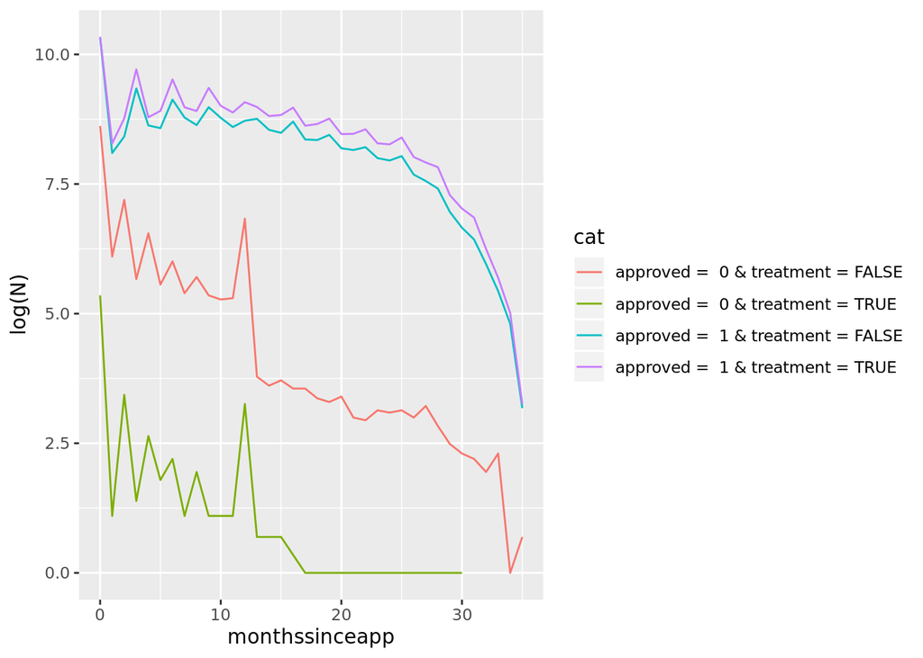

```r
monthsummary <- creditreports37[,.N,by=.(approved,treatment,monthssinceapp)]
monthsummary[,cat:=paste("approved = ",monthsummary$approved,"& treatment =",monthsummary$treatment)]

ggplot(monthsummary[monthssinceapp<36],aes(x=monthssinceapp,y=log(N),color=cat)) + geom_line()
```

## Regressions: Impact of treatment on future financial condition

- FICO score of treated applicants drop
- Treated applicants have more loans in the first year. i.e. credit constraints binding?
- Treated applicants are more likely to default on credit cards
- Treated applicants are less likely to purchase a home
- Treated applicants are less likely to purchase a new vehicle

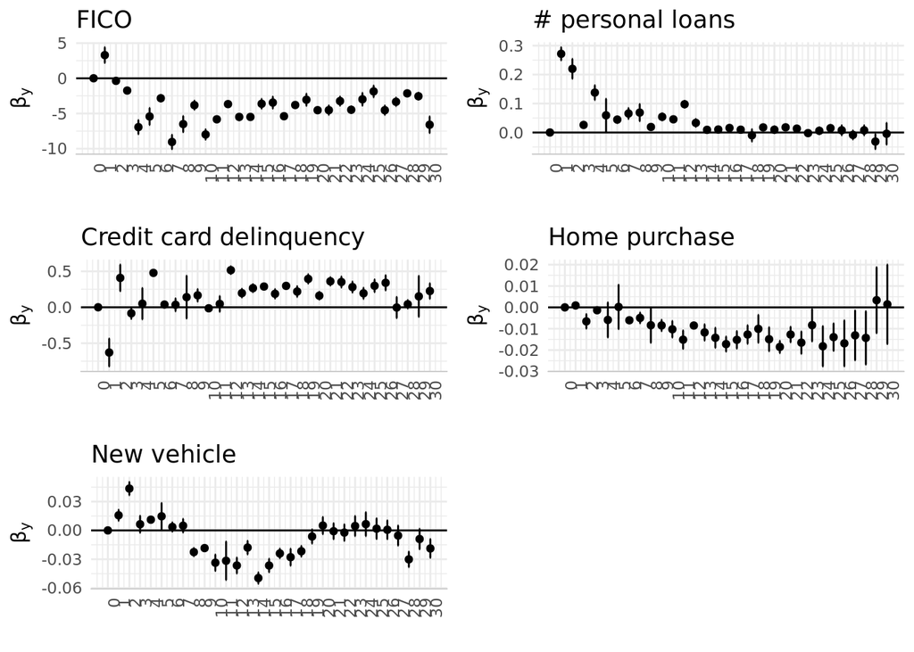

```r
regs <- list()

regs[[1]] <- felm(fico~treatment*factor(monthssinceapp)+selected_contract_years+ficoatorigination+log(raising_amount)|year+applicationyear+use_of_funds|0|applicationyear,data=creditreports37[monthssinceapp<=30 ])
regs[[2]] <- felm(number_of_personal_loans~treatment*factor(monthssinceapp)+selected_contract_years+ficoatorigination+log(raising_amount)|year+applicationyear+use_of_funds|0|applicationyear,data=creditreports37[monthssinceapp<=30 ])
regs[[3]] <- felm(creditcarddelinq~treatment*factor(monthssinceapp)+selected_contract_years+ficoatorigination+log(raising_amount)|year+applicationyear+use_of_funds|0|applicationyear,data=creditreports37[monthssinceapp<=30 ])
regs[[4]] <- felm(mortgage~treatment*factor(monthssinceapp)+selected_contract_years+ficoatorigination+log(raising_amount)|year+applicationyear+use_of_funds|0|applicationyear,data=creditreports37[monthssinceapp<=30 &  init_mortgage_balance==0])
regs[[5]] <- felm(au06s_number_of_auto_trades_opened_in_past_6_months~treatment*factor(monthssinceapp)+selected_contract_years+ficoatorigination+log(raising_amount)|year+applicationyear+use_of_funds|0|applicationyear,data=creditreports37[monthssinceapp<=30 ])

# printtable(regs)

gr <- list()
gr[[1]] <- coef_plot_1reg(regs[[1]],"treatmentTRUE:factor(monthssinceapp)",0)+ggtitle("FICO")
gr[[2]] <- coef_plot_1reg(regs[[2]],"treatmentTRUE:factor(monthssinceapp)",0)+ggtitle("# personal loans")
gr[[3]] <- coef_plot_1reg(regs[[3]],"treatmentTRUE:factor(monthssinceapp)",0)+ggtitle("Credit card delinquency")
gr[[4]] <- coef_plot_1reg(regs[[4]],"treatmentTRUE:factor(monthssinceapp)",0)+ggtitle("Home purchase")
gr[[5]] <- coef_plot_1reg(regs[[5]],"treatmentTRUE:factor(monthssinceapp)",0)+ggtitle("New vehicle")

grid.arrange(gr[[1]],gr[[2]],gr[[3]],gr[[4]],gr[[5]],ncol=2)
```

# Upstart’s decision to drop the minimum FICO score requirement to 620 from 640 in July 2016 as an experiment

```r
res <- dbSendQuery(hbrstudy,"
            select
              a.created_at,
              a.decision_status,
              a.selected_contract_years,
              a.use_of_funds,
              b.raising_amount,
              b.upstart_application_id,
              c.annual_income,
              c.dti,
              d.get_fico_score as ficoatorigination,
              b.user_account_id,
              f.pricing_reason
            from monolith.upstart_applications as a
            LEFT JOIN monolith.user_applications as b
            on a.id = b.upstart_application_id
            LEFT JOIN monolith.pricing_outputs as c
            on a.selected_pricing_output_id = c.id
            LEFT JOIN transunion.credit_reports as d
            on c.credit_report_id = d.id
            LEFT JOIN monolith.pricings as f
            on a.selected_pricing_output_id = f.selected_pricing_output_id
            where a.created_at > '2015-01-01' and a.created_at < '2017-12-31' and ficoatorigination<700")
apps640 <- dbFetch(res, n=-1)
dbClearResult(res)

apps640 <- data.table(apps640)

apps640[,created_at:=as.Date(apps640$created_at)]

apps640[,applicationmonth:=as.Date(paste0(substr(as.character(apps640$created_at),1,7),"-01"))]

apps640[,year:=year(apps640$created_at)]

apps640[,approved:=ifelse(apps640$decision_status %in% c("funded","failed_to_fund"),1,0)]

apps640[,analyticsample:=ifelse(apps640$decision_status %in% c("funded","failed_to_fund","disqualified"),1,0)]

apps640[,fico10bin:=floor(apps640$ficoatorigination/10)*10]

apps640[,ficoless640:=ifelse(apps640$ficoatorigination<640,1,0)]

apps640[,afterJune2016:= ifelse(apps640$applicationmonth>="2016-06-01",1,0)]

apps640 <- apps640[!is.na(apps640$ficoatorigination)]
```

## FICO Distribution By Year- Funded Applications

- Any idea about these spikes? Something to do with the default model?

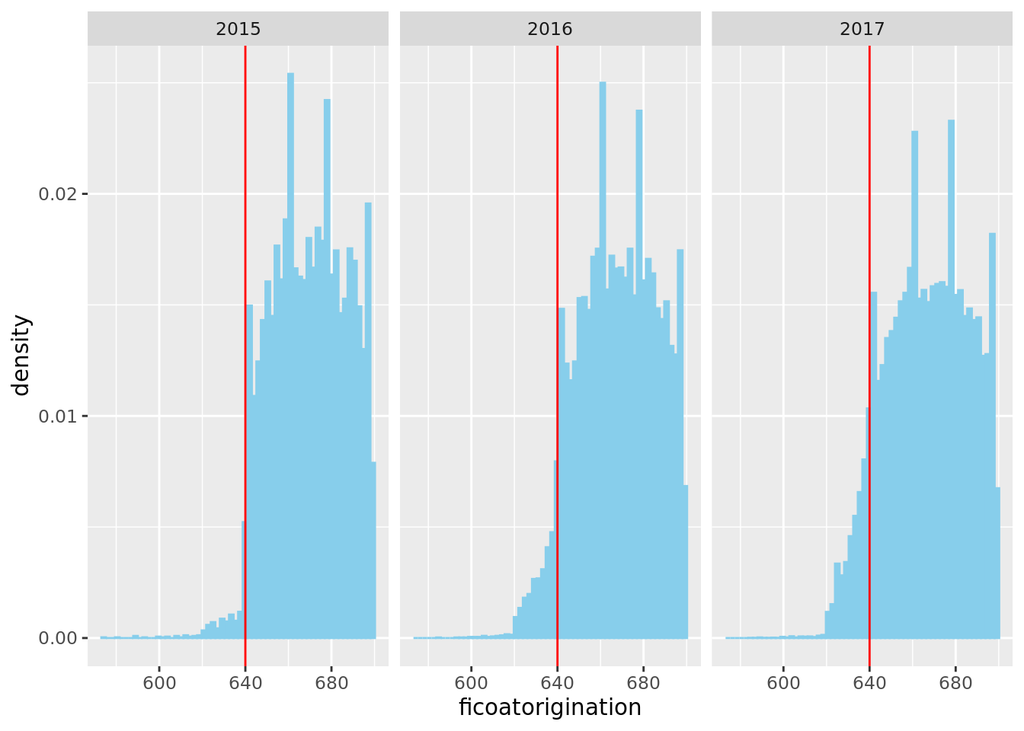

```r
ggplot(apps640[decision_status=="funded"],aes(x=ficoatorigination,y = ..density..))+geom_histogram(color="skyblue", fill="skyblue",bins=60)+
  geom_vline(aes(xintercept = 640), colour="red")+
  facet_wrap(~year, ncol = 3)
```

## Fraction of approved loans with FICO less than 640

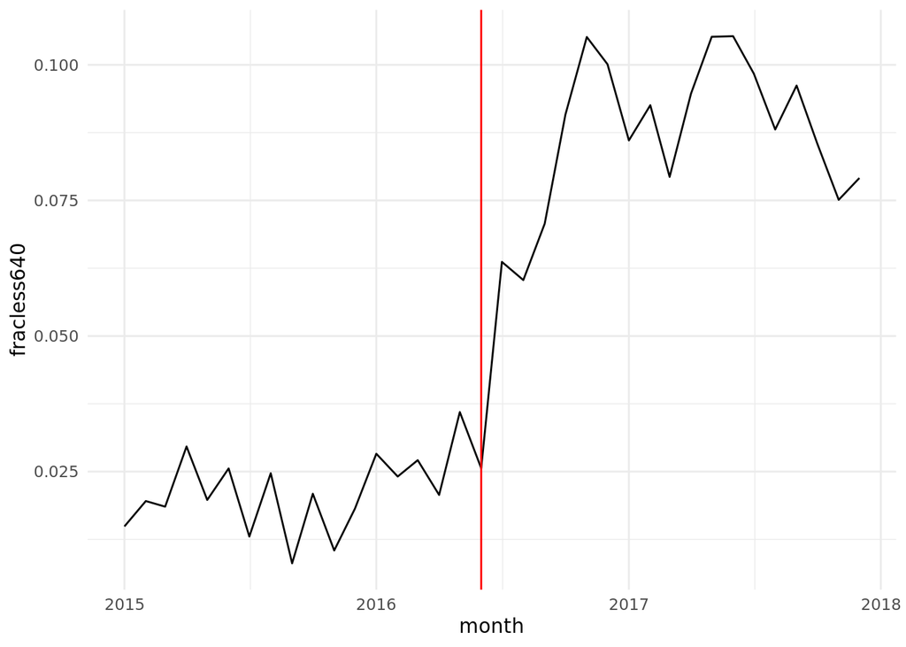

```r
less640 = apps640[apps640$approved==1 & !is.na(apps640$ficoatorigination),.N,by=.(applicationmonth,ficoless640)]

less640 = dcast(less640,applicationmonth~ficoless640,fun.aggregate = sum)

names(less640) = c("month","more","less")

less640 = data.table(less640)
less640[,fracless640:=less640$less/(less640$less+less640$more)]

ggplot(less640,aes(x=month,y=fracless640))+geom_line()+theme_minimal()+geom_vline(aes(xintercept = as.Date("2016-06-01")), colour="red")
```

## Probability of Approval when FICO is less than 640

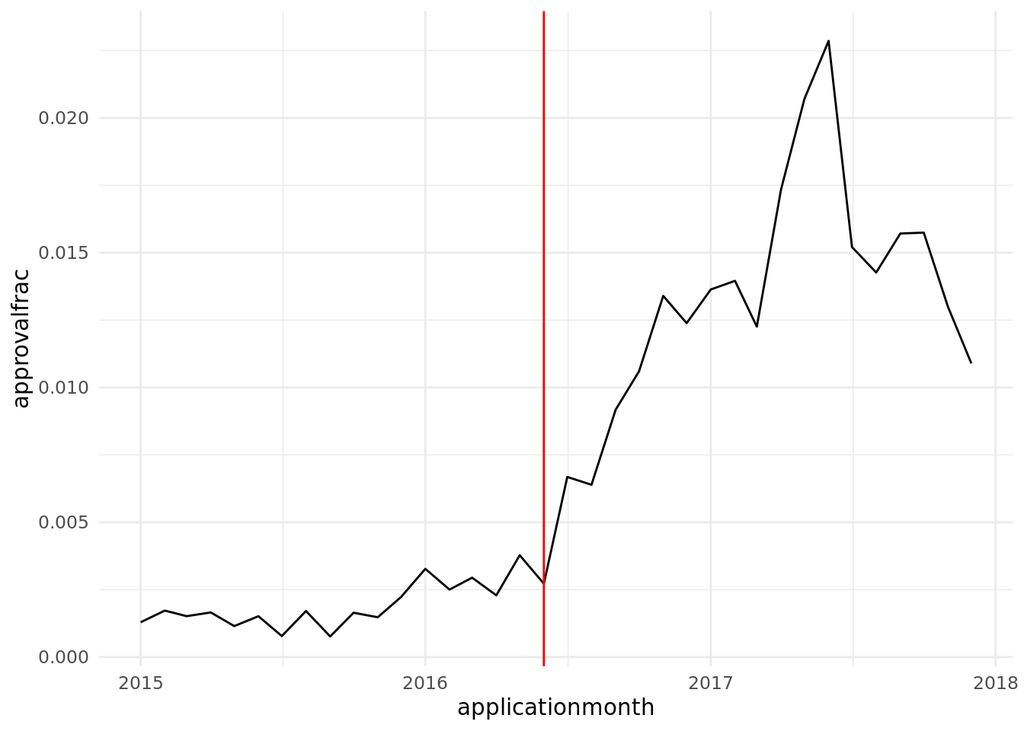

```r
approvalpct = apps640[apps640$ficoless640==1 & !is.na(apps640$ficoatorigination),.(approvalfrac=mean(approved,na.rm=TRUE)),by=.(applicationmonth)]

ggplot(approvalpct,aes(x=applicationmonth,y=approvalfrac))+geom_line()+theme_minimal()+geom_vline(aes(xintercept = as.Date("2016-06-01")), colour="red")
```

```r
# regs <- list()
# regs[[1]] <- felm(approved~factor(applicationmonth),data=apps640[ficoless640==1])
#
# coef_plot_1reg(regs[[1]],"factor(applicationmonth)",0)
```

## Credit reports

```r
res <- dbSendQuery(hbrstudy,"
            select
                a.get_fico_score as fico,
                a.num_inquiries_past_6_months,
                a.created_at,
                a.at36_months_since_most_recent_delinquency as months_since_delinquency,
                a.bc101s_total_balance_of_all_credit_card_trades_verified_in_past_12_months as credit_card_balance_12_months,
                a.individual_credit_history_days,
                a.monthly_mortgage,
                a.mortgage_balance,
                a.number_of_personal_loans,
                a.total_monthly_payments_excluding_mortgage,
                a.total_num_open_accounts,
                a.num_trades_currently_delinquent,
                a.open_personal_loan_balance,
                a.at02s_number_of_open_trades,
                a.at05_number_of_trades_opened_in_past_3_months,
                a.au01s_number_of_auto_trades,
                a.au06s_number_of_auto_trades_opened_in_past_6_months,
                a.bc107s_number_of_30_and_60_days_past_due_ratings_on_credit_card_trades,
                a.bc108s_number_of_90_or_more_days_past_due_ratings_on_credit_card_trades,
                b.credit_report_id,
                b.user_account_id
            from transunion.credit_reports as a
            LEFT JOIN monolith.credit_report_summaries as b
            on b.credit_report_id = a.id
            where b.user_account_id in
            (select
            b.user_account_id
            from monolith.upstart_applications as a
            LEFT JOIN monolith.user_applications as b
            on a.id = b.upstart_application_id
            LEFT JOIN monolith.pricing_outputs as c
            on a.selected_pricing_output_id = c.id
            LEFT JOIN transunion.credit_reports as d
            on c.credit_report_id = d.id
            where a.created_at > '2015-01-01' and a.created_at < '2017-12-31'
            and d.get_fico_score<700)")
creditreports640 <- dbFetch(res, n=-1)
dbClearResult(res)

creditreports640 <- data.table(creditreports640)
creditreports640[,created_at:=as.Date(created_at)]

creditreports640 <- creditreports640[!is.na(fico)]
creditreports640 <- creditreports640[!duplicated(credit_report_id)]
creditreports640 <- creditreports640[!duplicated(creditreports640[,c("created_at","user_account_id")])]

creditreports640[,creditcarddelinq:=bc107s_number_of_30_and_60_days_past_due_ratings_on_credit_card_trades + bc108s_number_of_90_or_more_days_past_due_ratings_on_credit_card_trades]


creditreportcount <- creditreports640[,.(count=.N,mindate=min(created_at),maxdate=max(created_at)),by=user_account_id]


creditreports640 <- merge(creditreports640,apps640[,c("user_account_id","approved","decision_status","use_of_funds","raising_amount","annual_income","applicationmonth","ficoatorigination","selected_contract_years","afterJune2016","ficoless640")],by="user_account_id")

# creditreports640 <- creditreports640[appdate<=created_at]

creditreports640[,monthssinceapp:=round(as.numeric(created_at - applicationmonth)/(365.25/12))]
creditreports640[,year:=year(created_at)]
creditreports640[,mortgage:=ifelse(mortgage_balance>0,1,0)]
```

## Subsequent availability of credit reports

- Why is there a big drop in number of credit reports for light blue line around month 20 and a significant increase around month 24?

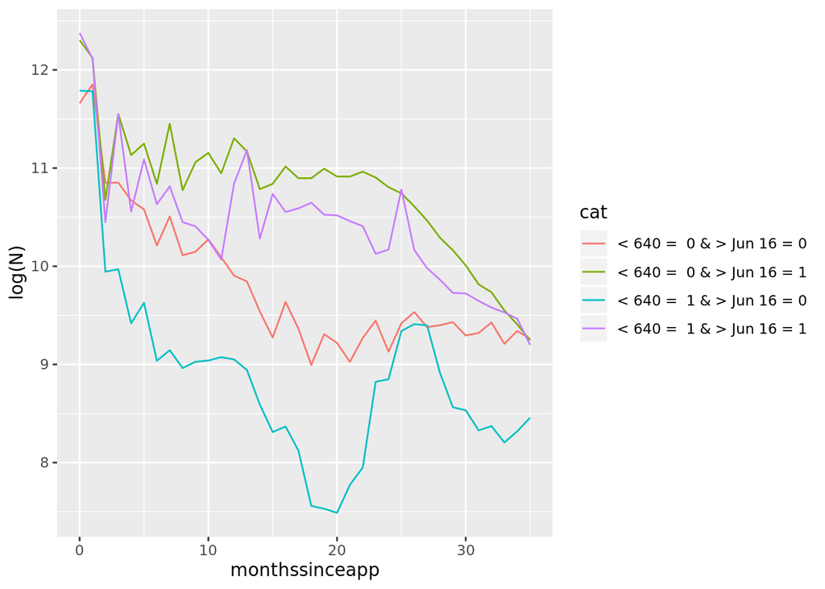

```r
monthsummary <- creditreports640[,.N,by=.(ficoless640,afterJune2016,monthssinceapp)]
monthsummary[,cat:=paste("< 640 = ",monthsummary$ficoless640,"& > Jun 16 =",monthsummary$afterJune2016)]

ggplot(monthsummary[monthssinceapp<36],aes(x=monthssinceapp,y=log(N),color=cat)) + geom_line()
```

## Regressions: Impact of treatment on future financial condition

What explains the breaks in following graphs? Particularly around 12th month and 24th month.

- FICO score of treated applicants drop
- Treated applicants are more likely to default on credit cards
- Treated applicants are less likely to purchase a home
- Treated applicants are less likely to purchase a new vehicle

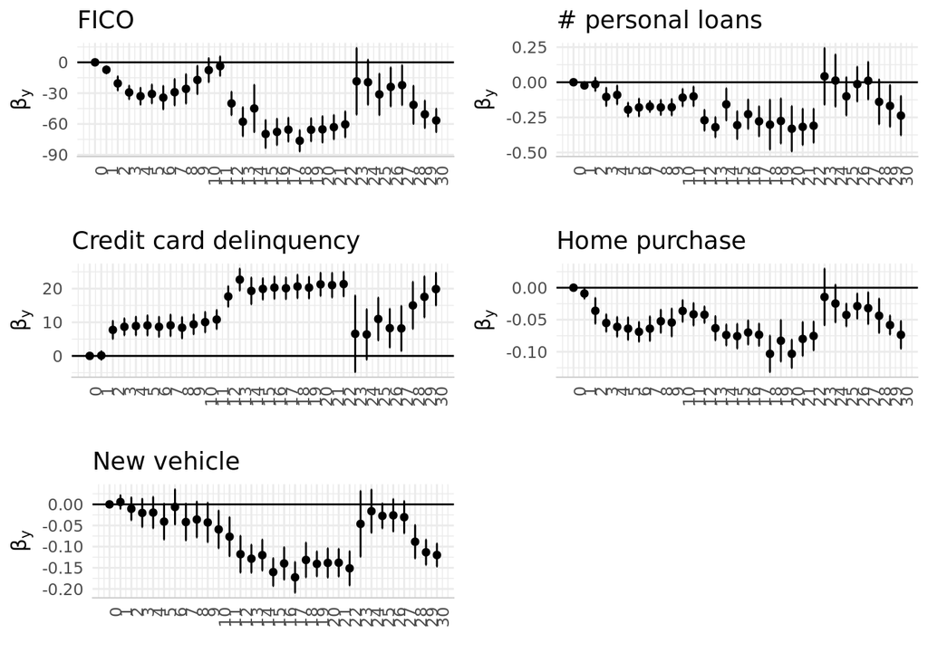

```r
regs <- list()

regs[[1]] <- felm(fico~afterJune2016*factor(monthssinceapp)+ficoatorigination+log(raising_amount)|0|0|applicationmonth,data=creditreports640[monthssinceapp<=30 & ficoatorigination<640])
regs[[2]] <- felm(number_of_personal_loans~afterJune2016*factor(monthssinceapp)+ficoatorigination+log(raising_amount)|0|0|applicationmonth,data=creditreports640[monthssinceapp<=30 & ficoatorigination<640])
regs[[3]] <- felm(creditcarddelinq~afterJune2016*factor(monthssinceapp)+ficoatorigination+log(raising_amount)|0|0|applicationmonth,data=creditreports640[monthssinceapp<=30 & ficoatorigination<640])
regs[[4]] <- felm(mortgage~afterJune2016*factor(monthssinceapp)+ficoatorigination+log(raising_amount)|0|0|applicationmonth,data=creditreports640[monthssinceapp<=30 & ficoatorigination<640 ])
regs[[5]] <- felm(au06s_number_of_auto_trades_opened_in_past_6_months~afterJune2016*factor(monthssinceapp)+ficoatorigination+log(raising_amount)|0|0|applicationmonth,data=creditreports640[monthssinceapp<=30 & ficoatorigination<640])


gr <- list()
gr[[1]] <- coef_plot_1reg(regs[[1]],"afterJune2016:factor(monthssinceapp)",0)+ggtitle("FICO")
gr[[2]] <- coef_plot_1reg(regs[[2]],"afterJune2016:factor(monthssinceapp)",0)+ggtitle("# personal loans")
gr[[3]] <- coef_plot_1reg(regs[[3]],"afterJune2016:factor(monthssinceapp)",0)+ggtitle("Credit card delinquency")
gr[[4]] <- coef_plot_1reg(regs[[4]],"afterJune2016:factor(monthssinceapp)",0)+ggtitle("Home purchase")
gr[[5]] <- coef_plot_1reg(regs[[5]],"afterJune2016:factor(monthssinceapp)",0)+ggtitle("New vehicle")

grid.arrange(gr[[1]],gr[[2]],gr[[3]],gr[[4]],gr[[5]],ncol=2)
```

```r
# res <- dbSendQuery(hbrstudy,"
#             select
#                 p.id
#                 from monolith.upstart_applications as p
#                 where p.upstart_id in
#             (select
#               a.upstart_id
#             from monolith.upstart_applications as a
#             LEFT JOIN monolith.user_applications as b
#             on a.id = b.upstart_application_id
#             LEFT JOIN monolith.pricing_outputs as c
#             on a.selected_pricing_output_id = c.id
#             LEFT JOIN transunion.credit_reports as d
#             on c.credit_report_id = d.id
#             LEFT JOIN monolith.pricings as f
#             on a.selected_pricing_output_id = f.selected_pricing_output_id
#             where a.created_at > '2016-01-01' and a.created_at < '2016-12-31' and d.get_fico_score<700)")
# t <- dbFetch(res, n=-1)
# dbClearResult(res)
```